# Tutorial1_Example2_Hyperspectral

## Exercise 2 - High Resolution Airborne Hyperspectral Data

**Objective**:

> - Explore NEON AOP Hyperspectral Data
> - Calculate/Visualize Spectral Indices
> - Unserpervised Machine Learning (Clustering)

**Data**: NEON AOP hyperspectral data from LTAR CPER

**Strategy**:

1. Load data and visualize at specific points.
2. Calculate and visualize spectral indices.
3. Subset and scale data to develop kmeans model.
4. Fit a Kmeans model with 8 clusters to data (we will impliment two different methods).
5. Predict and visualize entire dataset.

**Parallel Algorithm Detail**

For parts 1 - 3 we will rely on [Dask](https://docs.dask.org/en/latest/) to extract, transform, and load (ETL) the hyperspectral data. Parts 4 - 5 we will use [Dask-ML](http://ml.dask.org/) wrappers on top of [scikit-learn](https://scikit-learn.org/stable/) (a well-known machine learning library) classifiers to parallelize computations across the cluster.

```python
%pylab inline
```

```python
import os
os.environ['GDAL_DATA'] = '/opt/conda/share/gdal'
import dask_jobqueue as jq
#import time
from dask.distributed import progress,wait,Client
import dask.array as da
import dask
import dask.dataframe as dd
import numpy as np
import pandas as pd
import xarray as xr
```

```python
from sklearn.cluster import MiniBatchKMeans
from dask_ml.wrappers import Incremental
from dask_ml.wrappers import ParallelPostFit
from dask_ml.preprocessing import StandardScaler
from dask_ml.cluster import KMeans
```

```python
partition='short,debug,brief-low,mem'
num_processes = 3
num_threads_per_processes = 20
mem = 3.2*num_processes*num_threads_per_processes
n_cores_per_job = num_processes*num_threads_per_processes
container = '/project/geospatial_tutorials/data_science_im_rs_latest.sif'

clust = jq.SLURMCluster(queue=partition,
                        processes=num_processes,
                        cores=n_cores_per_job,
                        memory=str(mem)+'GB',
                        interface='ib0',
                        local_directory='$TMPDIR',
                        death_timeout=60,
                        python='singularity exec --bind /usr/lib64 --bind /scinet01 --bind /software/7/apps/envi/bin/ '+container+' python',
                        walltime='00:30:00')
cl=Client(clust)

dash_board = cl.scheduler.address.split('//')[1].split(':')[0]+":"+str(cl.scheduler_info()['services']['dashboard'])
ssh_command = 'ssh -N -L 8787:'+dash_board+' '+os.environ["USER"]+'@login.scinet.science'
print('To port forward diagnostics use:\n'+ssh_command)
cl
```

```
To port forward diagnostics use:
ssh -N -L 8787:10.1.8.20:8787 rowan.gaffney@login.scinet.science
```

Client

- **Scheduler:** tcp://10.1.8.20:46840

- **Dashboard:** http://10.1.8.20:8787/status

Cluster

- **Workers:** 0

- **Cores:** 0

- **Memory:** 0 B

```python
clust.scale(n=18)
```

```python
cl
```

Client

- **Scheduler:** tcp://10.1.8.20:46840

- **Dashboard:** http://10.1.8.20:8787/status

Cluster

- **Workers:** 18

- **Cores:** 360

- **Memory:** 1.15 TB

### **Load and Visualize Spectral Data**

```python
#Function to exclude bands with H2O or CO2 absorption
def band_list():
    good_bands1 = np.linspace(0,188,189).astype(int)
    good_bands3 = np.linspace(211,269,269-211+1).astype(int)
    good_bands5 = np.linspace(316,425,425-316+1).astype(int)
    good_bands = np.hstack([good_bands1,good_bands3,good_bands5])
    bad_bands2 = np.linspace(189,210,210-189+1).astype(int)
    bad_bands4 = np.linspace(270,315,315-270+1).astype(int)
    bad_bands = np.hstack([bad_bands2,bad_bands4])
    return(good_bands,bad_bands)
```

```python
#Persist the data to memory
d_all = xr.open_zarr('/project/geospatial_tutorials/tutorial_1/data/neon_2017_mosaic_brdf_corr.zarr',group='reflectance').isel(wl=band_list()[0]).chunk({'x':'auto','y':'auto','wl':-1}).persist()
d_all
```

```
<xarray.Dataset>
Dimensions:      (wl: 358, x: 12050, y: 13092)
Coordinates:
  * wl           (wl) float64 381.3 386.3 391.3 ... 2.5e+03 2.505e+03 2.51e+03
  * x            (x) float64 5.166e+05 5.166e+05 ... 5.287e+05 5.287e+05
  * y            (y) float64 4.526e+06 4.526e+06 ... 4.513e+06 4.513e+06
Data variables:
    reflectance  (y, x, wl) int16 dask.array<shape=(13092, 12050, 358), chunksize=(776, 241, 358)>
```

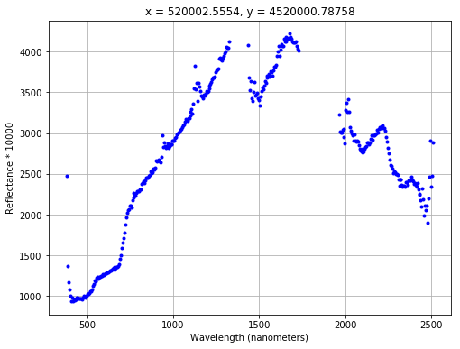

```python
#Plot the spectral signature at point
plt.figure(figsize=(8,6))
d_all.reflectance.interp(x=520002.5554,y=4520000.78758,method='linear').plot.line('b.')
plt.ylabel('Reflectance * 10000')
plt.xlabel('Wavelength (nanometers)')
plt.grid()
```